# Looking at Visual Statistics with `ggdibbler`

Harriet Mason, Dianne Cook, Sarah Goodwin, Susan Vanderplas

Monash University, Australia

# Part 1: Walktober

## Walktober

Our department had a walkathon in october where we all competed to see how many steps we could walk each day

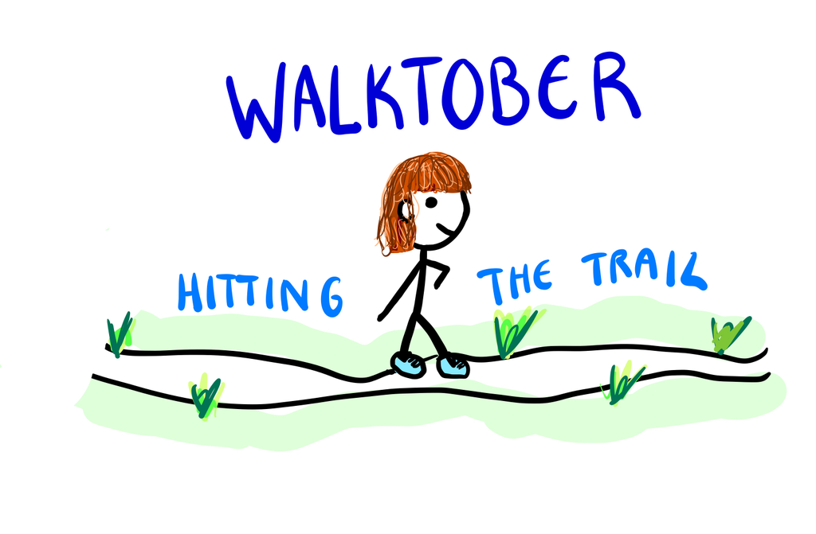

## Data quality angel

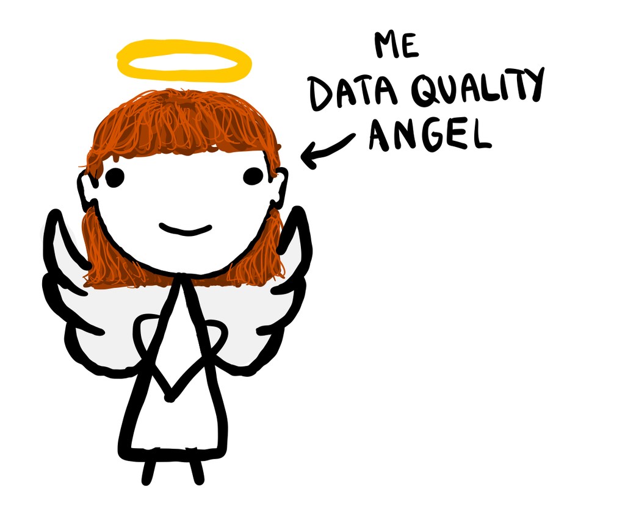

Before the competition started, I searched up the most accurate and cost effective pedometer

## Pedometer = bad

- It turns out, pedometers are wildly inaccurate

[figure not shown]

## Data quality demons

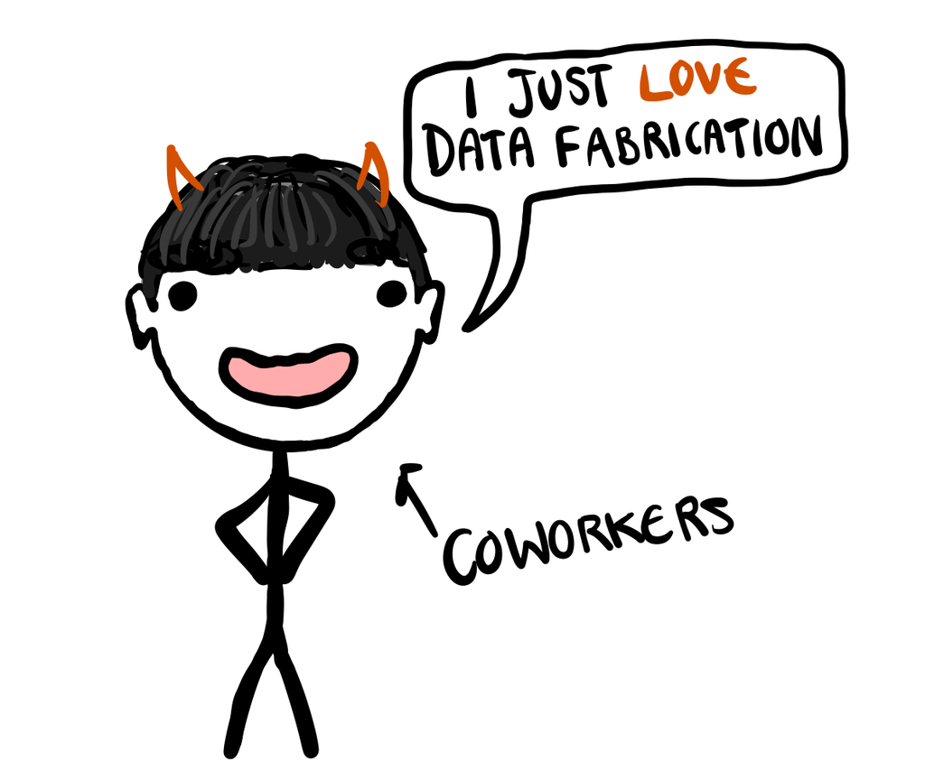

- It turns out I was the ONLY person concerned about data quality
- We conducted a survey after walktober, to see if we could quantify the pedometer error
- Turns out the measurement error was the least of my worries

## Survey response

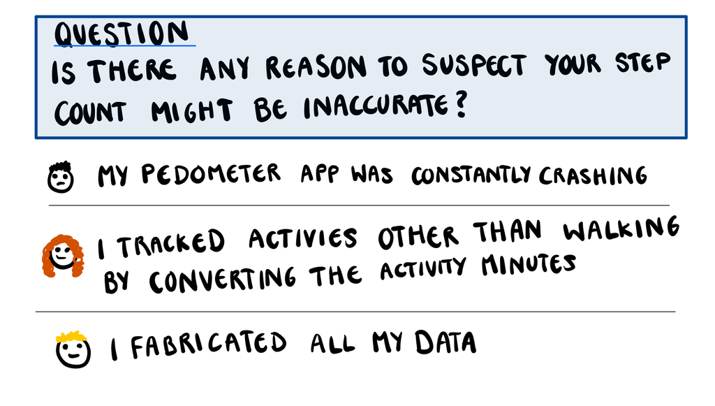

## The visualisation challenge

I had to just use the raw data without incorporating my pedometer research

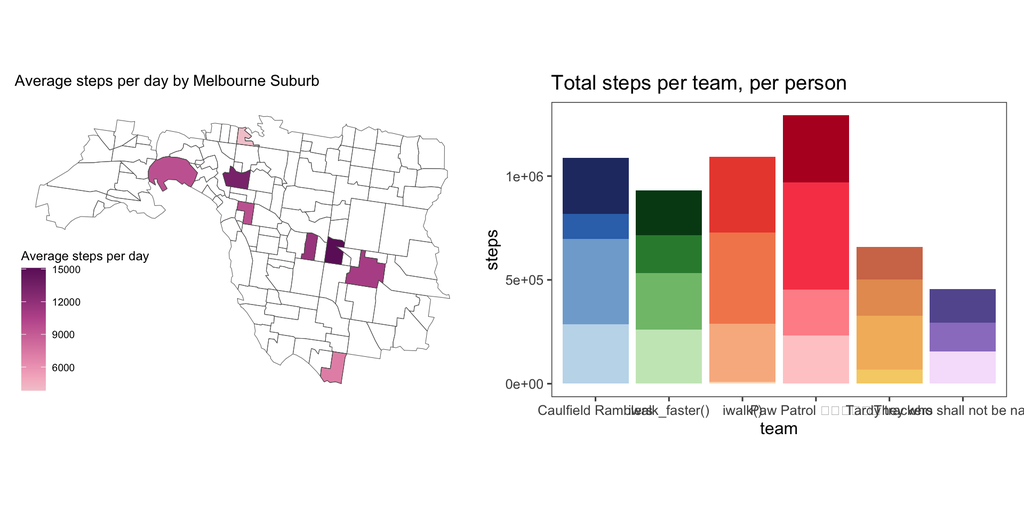

## Not even an uncommon scenario

Often our data is….

- Unavailable
  - e.g. anonymised data, measurement error, etc.
- Non-deterministic
  - e.g. bounded data, estimated values, etc.
- or Theoretical
  - e.g. estimates based on theory, latent variables, etc

## Data type already exists

```
# A tibble: 4 × 3
                steps_dist team    name
                    <dist> <chr>   <chr>
1 N(23679, 4633687)[0,Inf) iwalk() A
2 N(18322, 2774223)[0,Inf) iwalk() A
3   N(24562, 5e+06)[0,Inf) iwalk() A
4 N(26128, 5642050)[0,Inf) iwalk() A
```

- Include pedometer uncertainty with `distributional`
  - Thank you Mitch, Matt, Alex, and Rob
  - Vectorised random variable
  - Our walktober examples are truncated normal distributions
- This is not a talk on `distributional`

## Density visualisations

When we have distributional inputs, we typically default to a density function

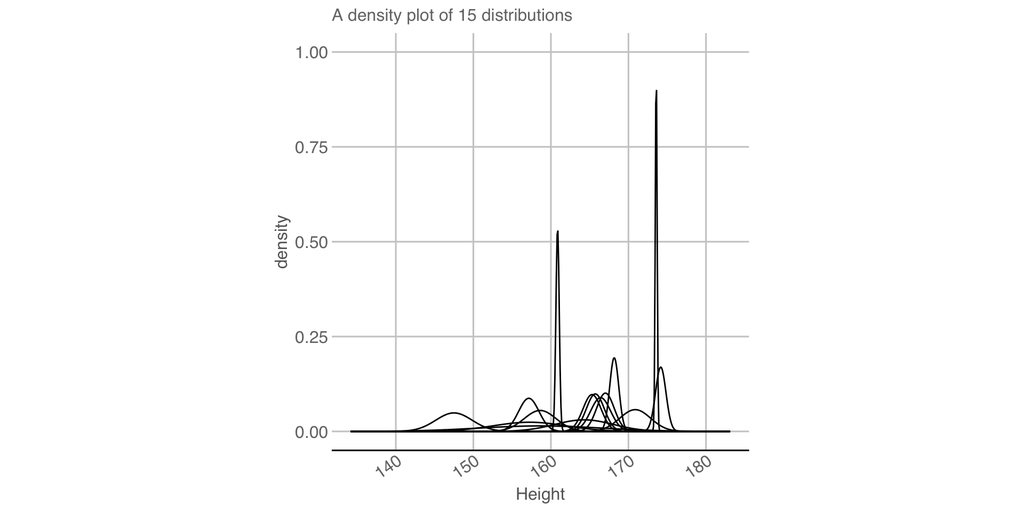

## Random inputs, not density plots

I want an uncertain version of MY walktober visualisations!

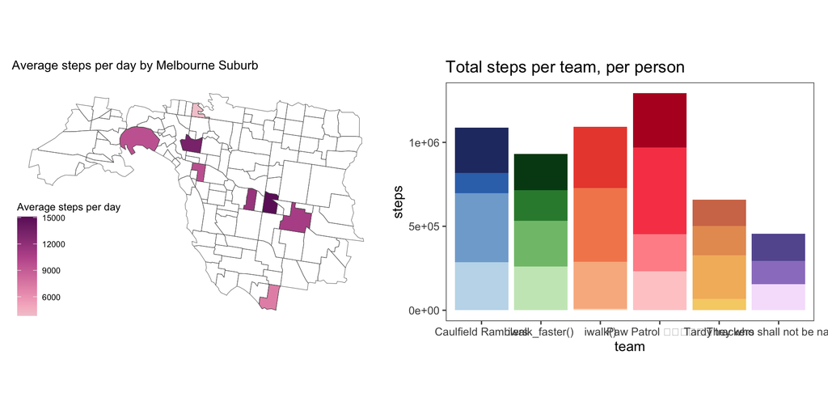

# Part 2: The Wishlist

## How should it look?

- Statistical validity should translates to perceptual ease
  - The higher the variance on an estimate, the harder that estimate is to extract from the plot

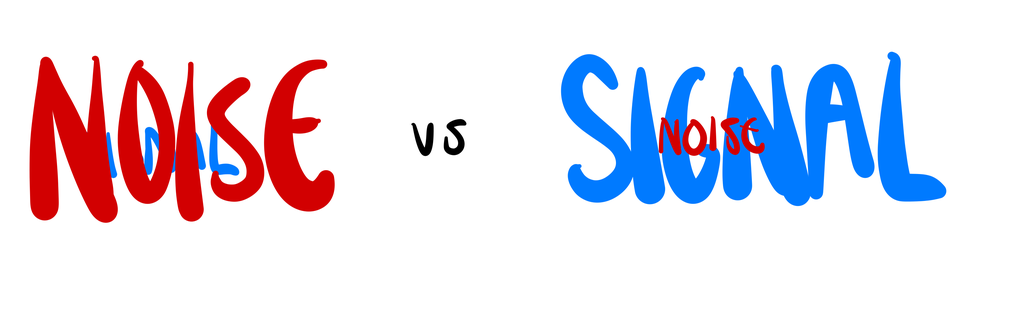

## Don’t want to just “show uncertainty”

- I want to do it in a way that is statistically sensible
- Statistical properties are what differentiate us from the animals

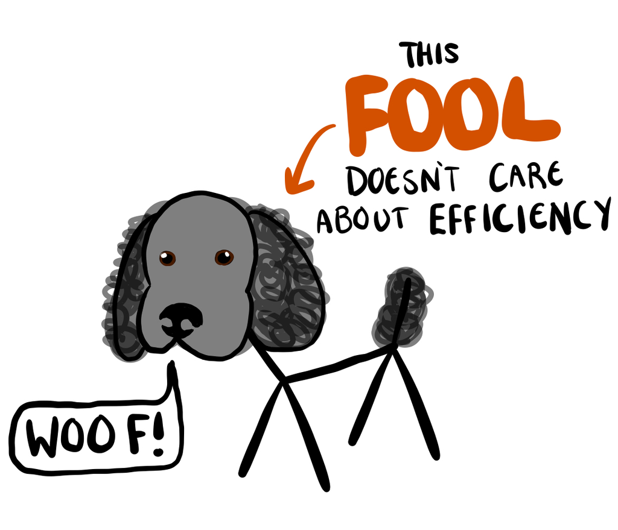

## What statistical properties?

Visualisations are functions

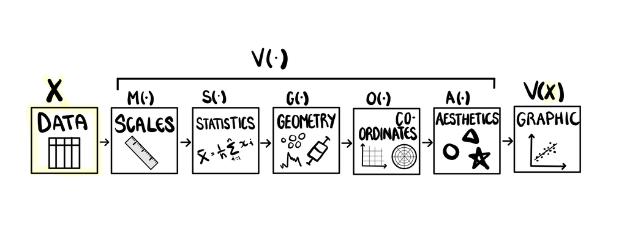

## What statistical properties?

… that are being applied to a random variable

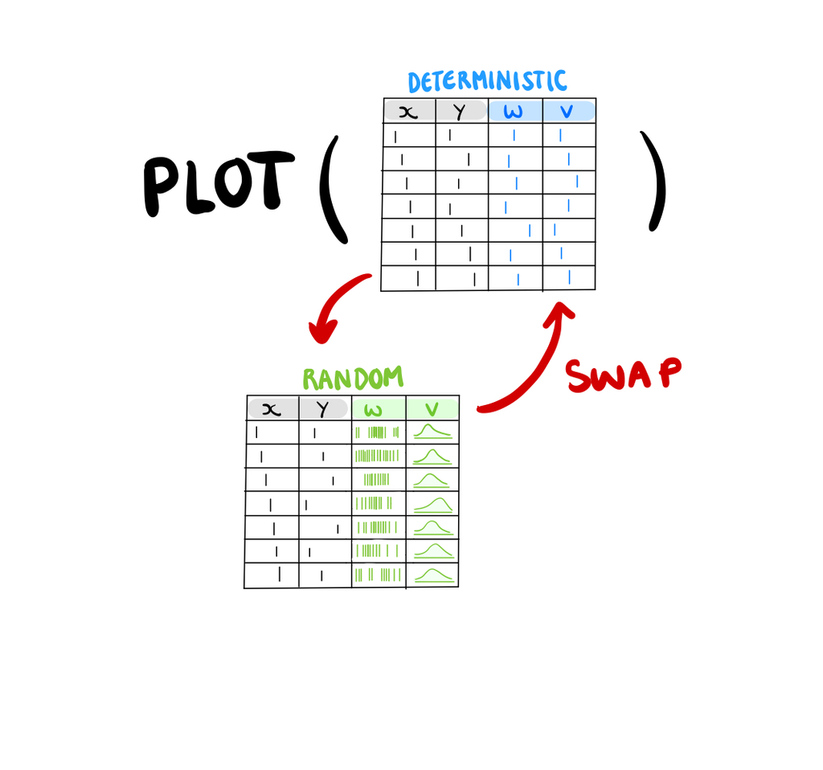

## What statistical properties?

So they should follow continuous mapping theorem

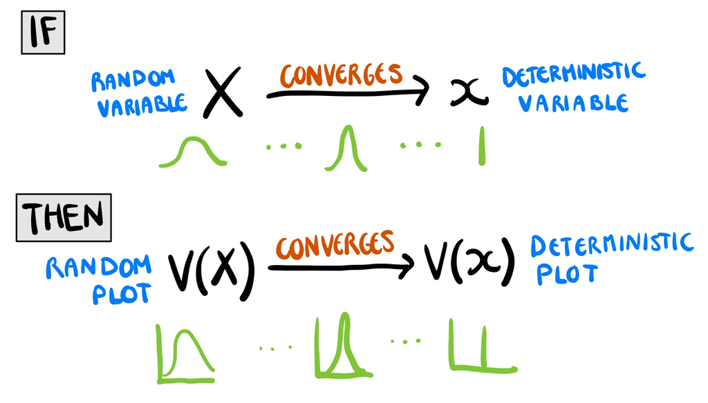

## A density plot under this system

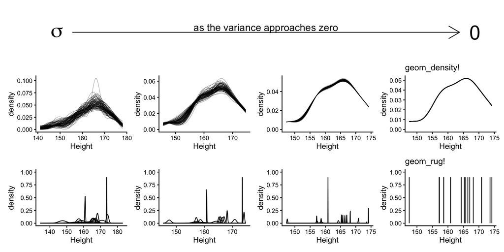

## Make this into a `ggplot2` extension

I want a package that does this for every `geom` & `stat`

[figure not shown]

## Minds eye code

The function is the same. The input that different

```r
# determinsitic ggplot
ggplot(deterministic_data) +
  geom_tile(aes(x=x, y=y, fill=z))

# random variable ggplot
ggplot(random_data) +
  geom_tile(aes(x=x, y=y, fill=random_z))
```

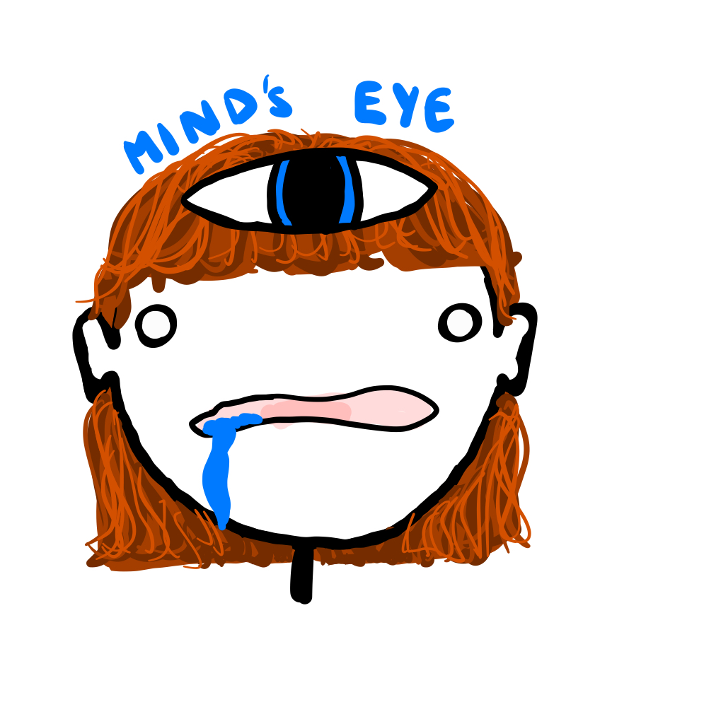

# Part 3: Making `ggdibbler`

## Its a simple problem…

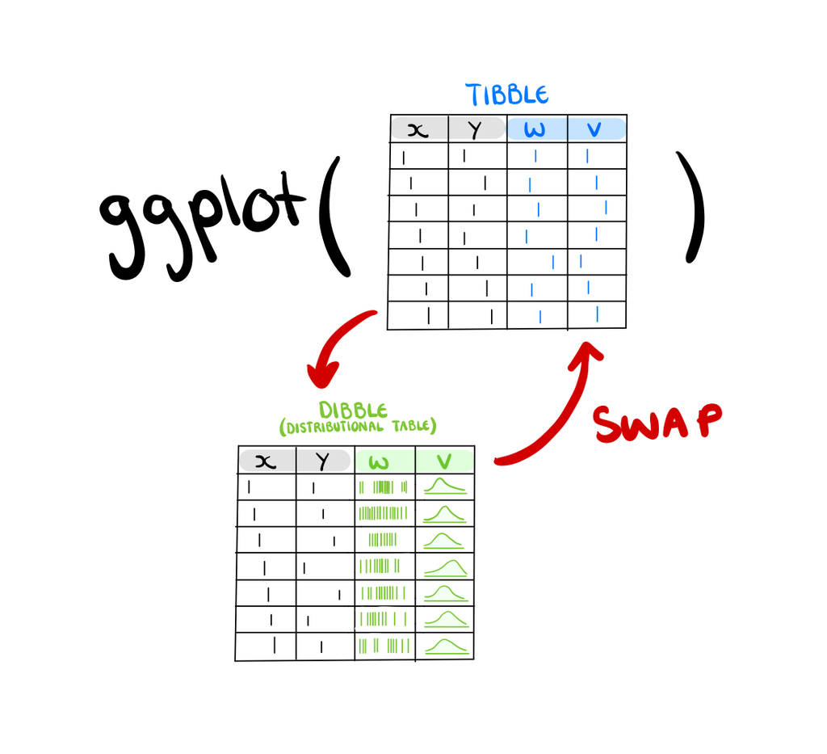

## … that we make even simpler

- Represent as a set of samples from the random matrix
- Only distribution representation that can be subbed into any `ggplot2` function
  - Mean/median brings us back to the original problem
  - PDF leads to the geom_rug problem
  - Quantiles need an ordering (problem in figure)

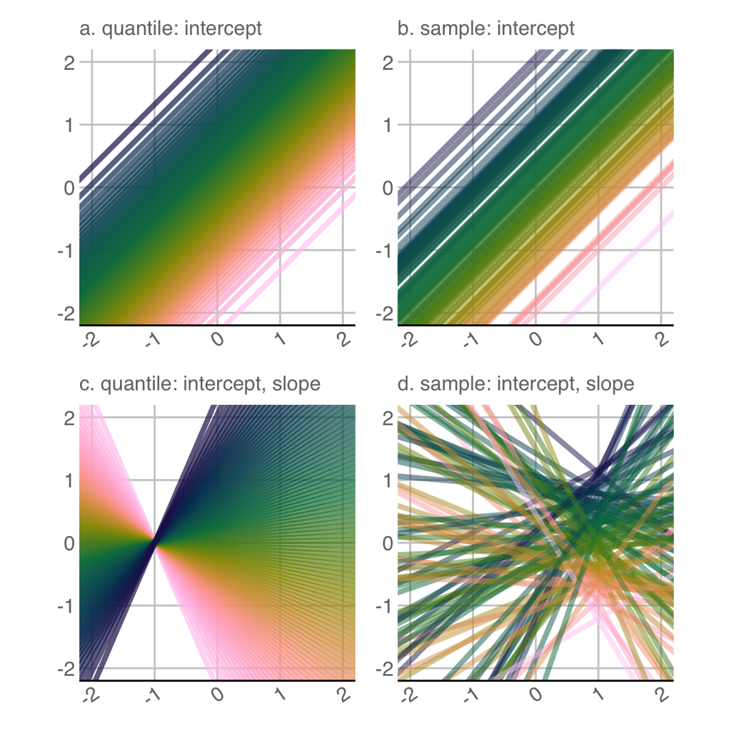

## … and even simpler again

- Start off with a choropleth map, `geom_sf`

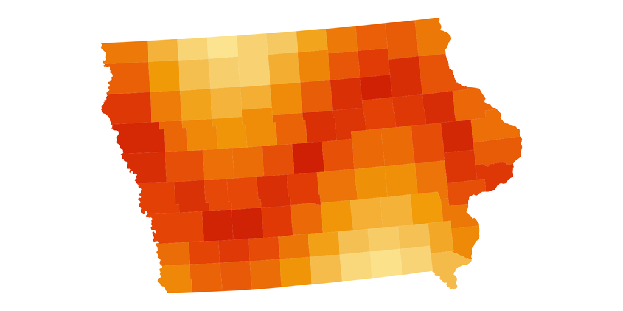

## If you have a simple problem…

The ggplot2 book has lots off good advice

[figure not shown]

## Not so simple errors

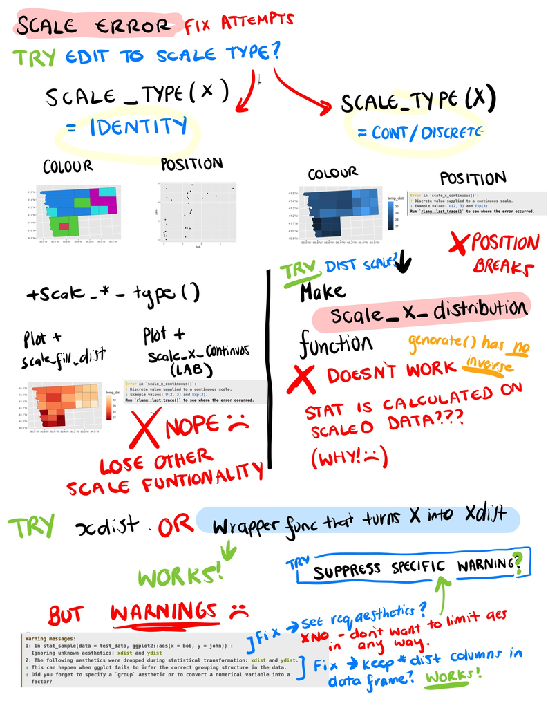

## Asking for help

[figure not shown]

## Asking for help

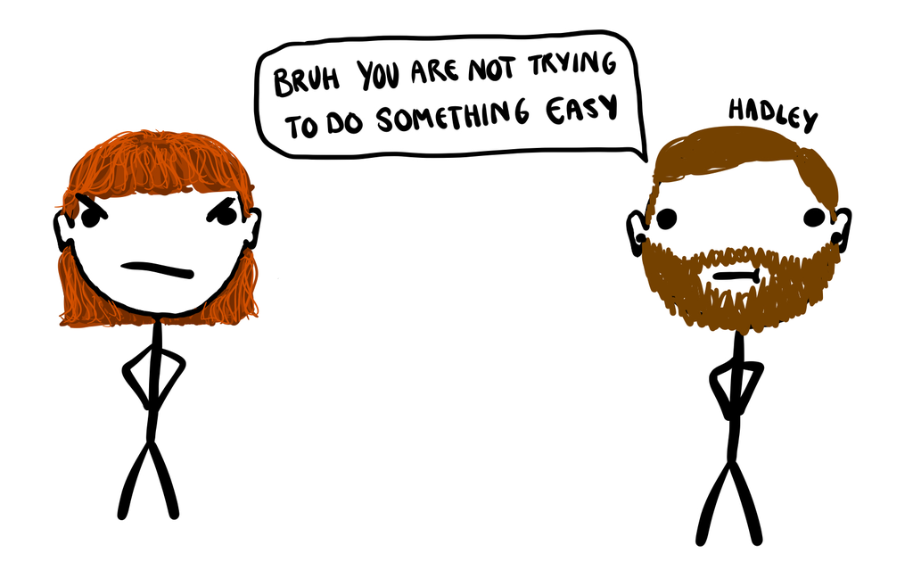

## Asking for help

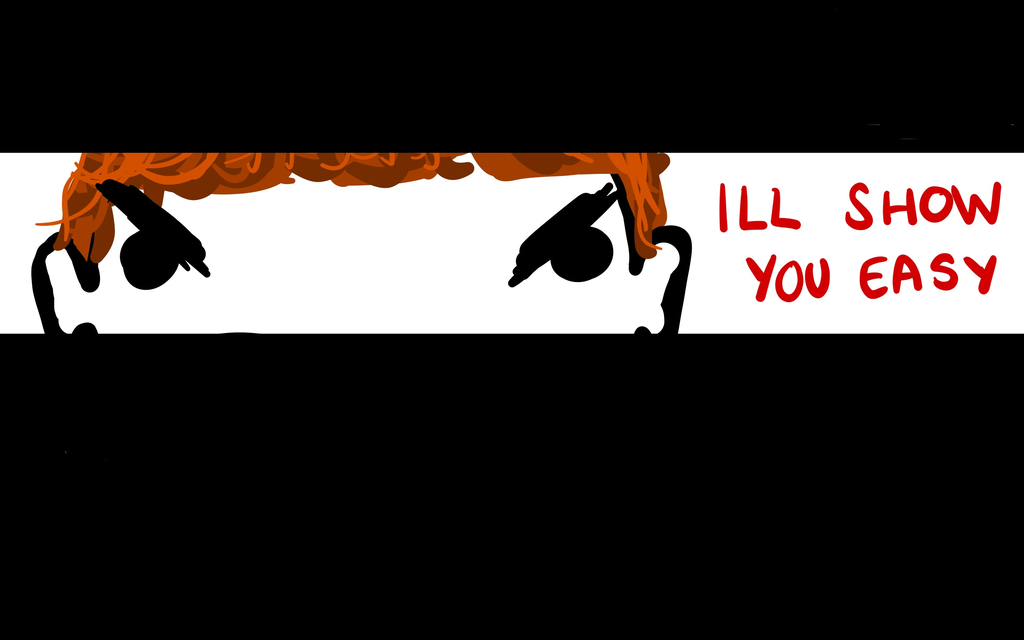

## Mania in the Github activity

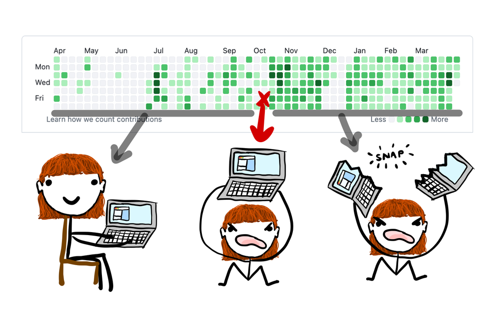

## Spatial Plots

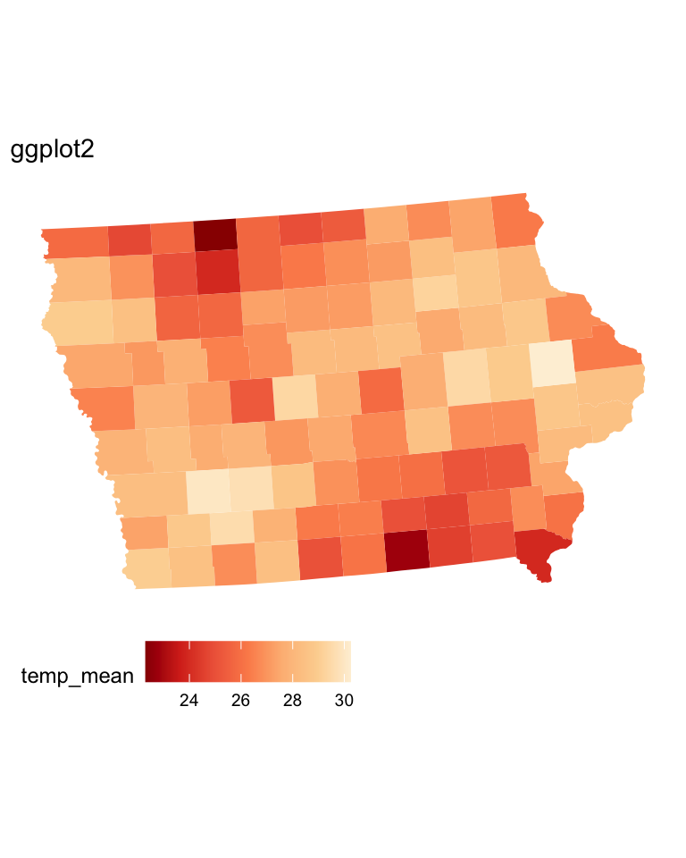

```r
ggplot(toy_temp_mean) +
  geom_sf(aes(geometry=county_geometry, fill=temp_mean), linewidth=0) +
  scale_fill_distiller(palette = "OrRd") +
  theme_map() +
  theme(legend.position = "bottom") +
  ggtitle("ggplot2")
```

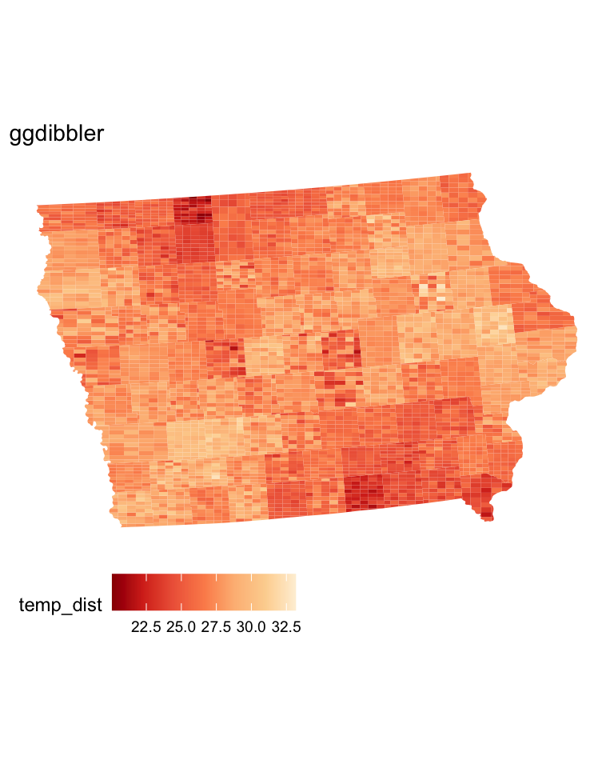

```r
ggplot(toy_temp_dist) +
  geom_sf_sample(aes(geometry = county_geometry, fill=temp_dist), linewidth=0, times=50) +
  scale_fill_distiller(palette = "OrRd") +
  theme_map() +
  theme(legend.position = "bottom") +
  ggtitle("ggdibbler")
```

## Uncertain EVERYTHING

The extension is TRIVIAL!

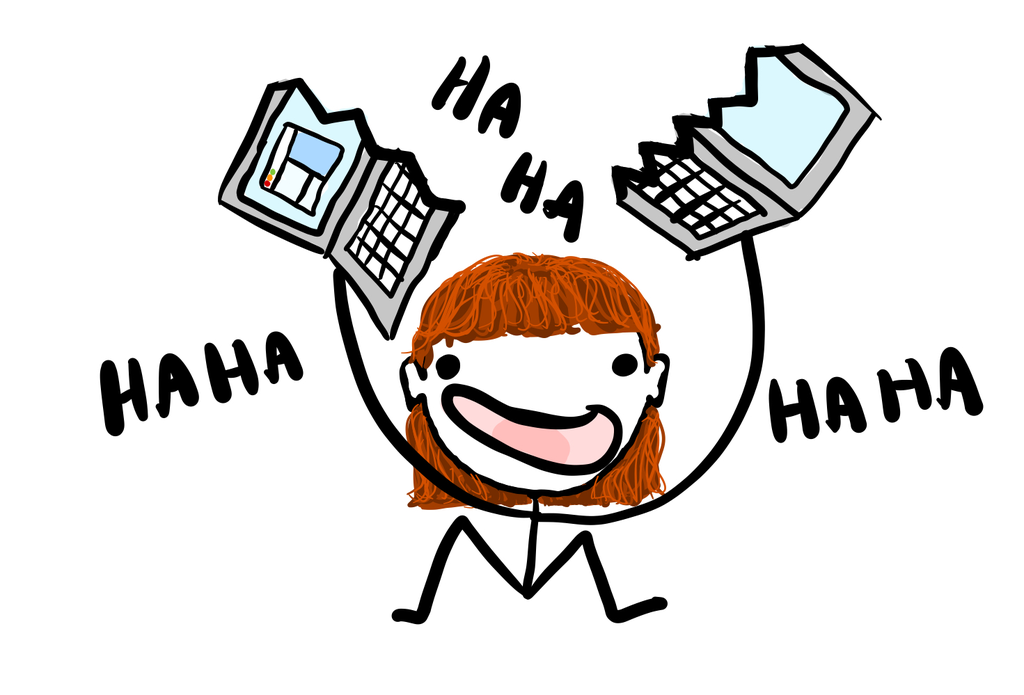

## Uncertain data sets!

Every data set used in the `ggplot2` documentation has a `distributional` version in `ggdibbler` where **EVERY** variable is a random variable.

- `diamonds` = `uncertain_diamonds`
- `mpg` = `uncertain_mpg`
- `mtcars` = `uncertain_mtcars`
- `faithful` = `uncertain_faithful`
- `economics`= `uncertain_economics`

## Any geom!

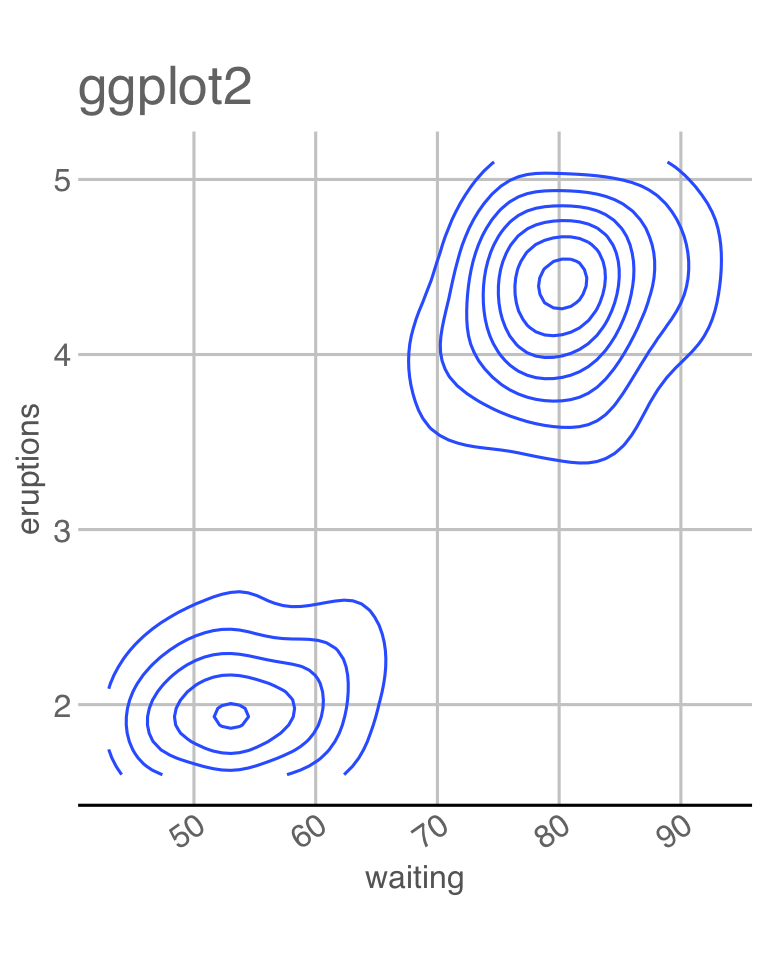

```r
ggplot(faithfuld, aes(waiting, eruptions, z = density)) +
  ggtitle("ggplot2") +
  geom_contour() +
  theme(aspect.ratio = 1)
```

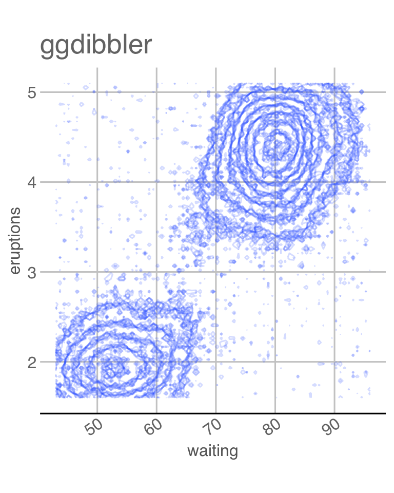

```r
ggplot(uncertain_faithfuld, aes(waiting, eruptions, z = density))+
  ggtitle("ggdibbler") +
  geom_contour_sample(alpha=0.2)+
  theme(aspect.ratio = 1)
```

## Any geom!

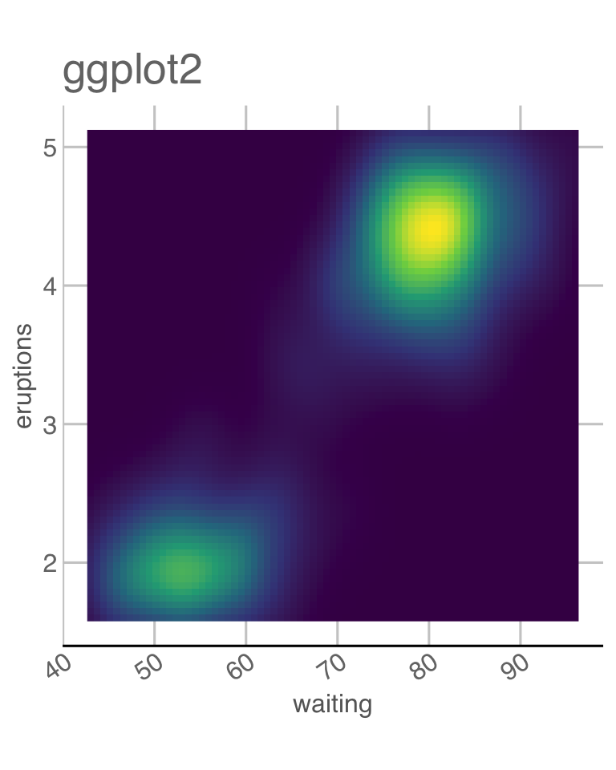

```r
ggplot(faithfuld, aes(waiting, eruptions)) +
  geom_raster(aes(fill = density)) +
  scale_fill_viridis_c() +
  theme(legend.position = "none") +
  ggtitle("ggplot2")
```

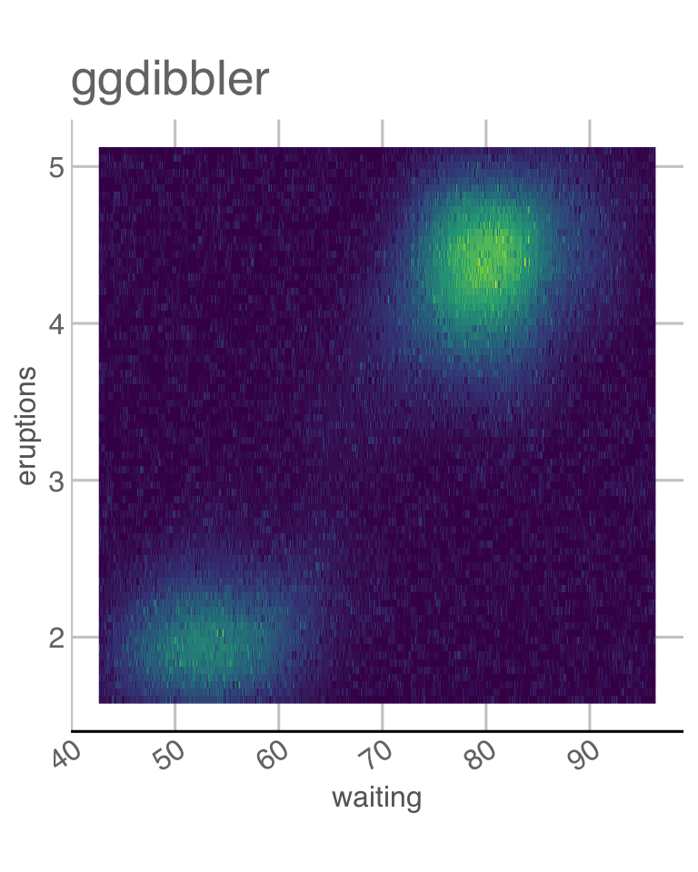

```r
ggplot(uncertain_faithfuld, aes(waiting, eruptions)) +
  geom_raster_sample(aes(fill = density2)) +
  scale_fill_viridis_c() +
  ggtitle("ggdibbler")+
  theme(legend.position = "none")
```